# Classification Techniques: Linear and Quadratic Discriminant Analysis, Logistic Regression

Liam Abbott

### Summary

The olive dataset analyzed in this report contains data on the chemical composition of 575 Italian olive oils, measured by the percentage composition of eight different fatty acids found in the lipid fraction of the oil. Each olive oil has an associated Region and Area label indicating the respective region and area of origin for that particular olive oil.

In this analysis, we conduct linear and quadratic discriminant analyses and multivariate logistic regression with the goal of assigning the correct region and area labels to each olive oil based on the composition of the fatty acids found in the oil.

|  | Region Training | Region Test | Area Training | Area Test |
| --- | --- | --- | --- | --- |
| Linear Discriminant Analysis | 1.17% | 1.61% | 5.65% | 11.29% |
| Quadratic Discriminant Analysis | 0.97% | 1.61% | 0.97% | 4.84% |
| Logistic Regression | 0.58% | 1.61% | 2.73% | 8.06% |

Overall, the task of classifying olive oils by area seemed to be harder than classifying by region, as the training and test error rates for area classification models tended to be higher.

This makes sense given that there are only 3 different regions of origin represented in the dataset, but 9 different areas of origin. There are likely several geographic ‘areas’ contained within each region, and so area classification is a more specific task.

The region classification error rates can be thought of as a lower bound on the area classification rates. Assuming that multiple areas comprise each region, it would be impossible for area classification to be more accurate than region classification given the same data.

### Region Analysis

The first part of this report will focus on the task of classifying the olive oils into one of 3 possible regions of origin.

Before building the models outlined above, it’s useful to look at pairwise and parallel coordinates plots of the data to visualize the class structure.

In each of the plots below, the colors correspond to the 3 different regions of origin found in the dataset:

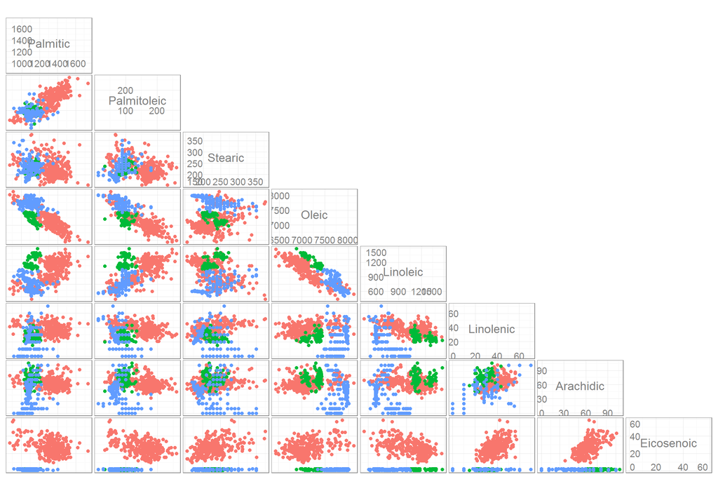

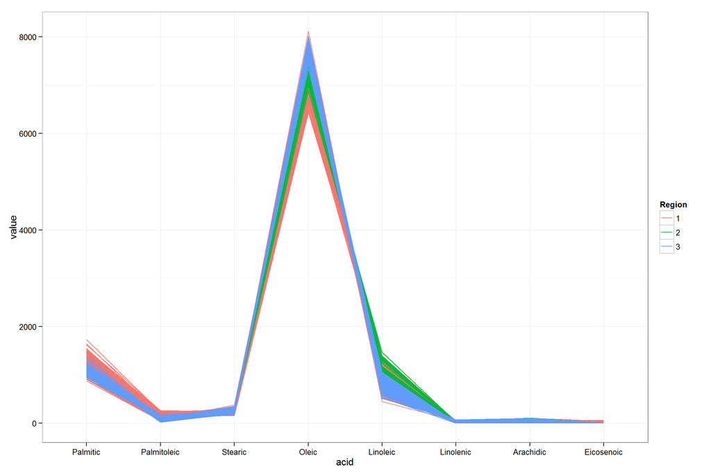

Because the typical values of different acids vary so much, it’s difficult to gain any insight into the class structure in terms of individual acids by looking at the parallel coordinates plot containing all 8 acids.

It makes more sense to create several parallel coordinate plots with acids grouped by typical values.

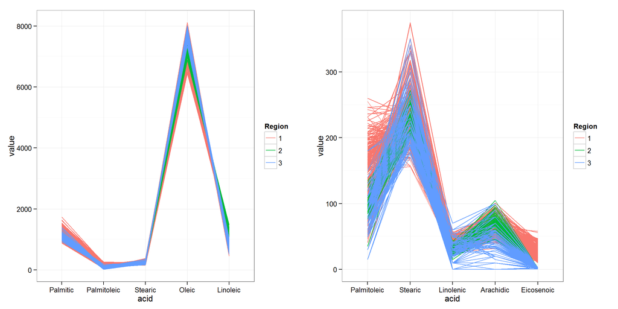

From these plots, it seems that Eicosenoic acid content clearly determines whether or not an olive oil is from region 1, as olive oils that are not from region 1 contain almost no Eicosenoic acid. In addition, it seems that olive oils from regions 2 and 3 have distinctly different Oleic acid content. Using these two variables, Eicosenoic and Oleic acid content, we should be able to build models capable of classifying the region a given olive oil is from with high accuracy. The analysis that follows focuses on these two variables.

Fitting a linear discriminant model to classify region of origin using the training data set and the Eicosenoic and Oleic variables, we get the following prior probabilities and group means:

|  | Region 1 | Region 2 | Region 3 |
| --- | --- | --- | --- |
| Prior Probability | 0.56 | 0.17 | 0.27 |
| Oleic Mean | 7111.71 | 7270.07 | 7779.84 |
| Eicosenoic Mean | 27.07 | 1.97 | 1.95 |

The classification rule seems to work well, as there are very few olive oils in the training or test datasets incorrectly classified, as seen in the tables below:

*LDA Training Classification Table:*

|  | Region 1 Actual | Region 2 Actual | Region 3 Actual |
| --- | --- | --- | --- |
| Region 1 Predicted | 286 | 0 | 0 |
| Region 2 Predicted | 3 | 87 | 3 |
| Region 3 Predicted | 0 | 0 | 134 |

*LDA Test Classification Table:*

|  | Region 1 Actual | Region 2 Actual | Region 3 Actual |
| --- | --- | --- | --- |
| Region 1 Predicted | 34 | 0 | 0 |
| Region 2 Predicted | 0 | 11 | 1 |
| Region 3 Predicted | 0 | 0 | 16 |

In the plot below, we can see the data projected onto the two linear discriminants:

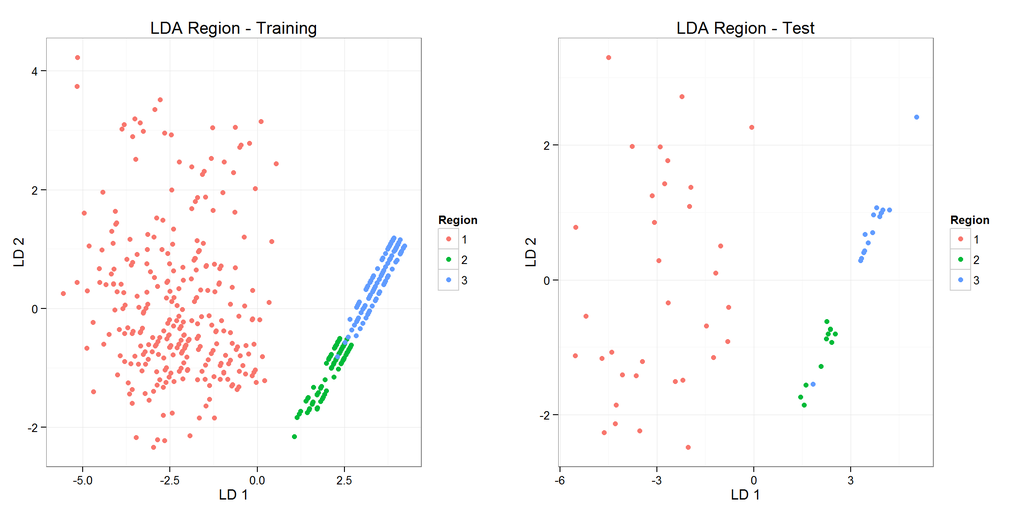

Fitting a quadratic discriminant model to classify region of origin, again using the training dataset and the Eicosenoic and Oleic variables, we get the following classification tables:

*QDA Training Classification Table:*

|  | Region 1 Actual | Region 2 Actual | Region 3 Actual |
| --- | --- | --- | --- |
| Region 1 Predicted | 289 | 0 | 0 |
| Region 2 Predicted | 0 | 87 | 5 |
| Region 3 Predicted | 0 | 0 | 132 |

*QDA Test Classification Table:*

|  | Region 1 Actual | Region 2 Actual | Region 3 Actual |
| --- | --- | --- | --- |
| Region 1 Predicted | 34 | 0 | 0 |
| Region 2 Predicted | 0 | 11 | 1 |
| Region 3 Predicted | 0 | 0 | 16 |

Fitting a multivariate logistic regression model to classify region of origin, again using the training dataset and the Eicosenoic and Oleic variables, we get the following classification tables:

*Logistic Regression Training Classification Table:*

|  | Region 1 Actual | Region 2 Actual | Region 3 Actual |
| --- | --- | --- | --- |
| Region 1 Predicted | 289 | 0 | 0 |
| Region 2 Predicted | 0 | 87 | 3 |
| Region 3 Predicted | 0 | 0 | 134 |

*Logistic Regression Test Classification Table:*

|  | Region 1 Actual | Region 2 Actual | Region 3 Actual |
| --- | --- | --- | --- |
| Region 1 Predicted | 34 | 0 | 0 |
| Region 2 Predicted | 0 | 11 | 1 |
| Region 3 Predicted | 0 | 0 | 16 |

### Area Analysis

As we did earlier, before building any models we look at pairwise and parallel coordinates plots of the data to visualize the class structure. In the plots below, the colors correspond to the nine different areas of origin found in the dataset:

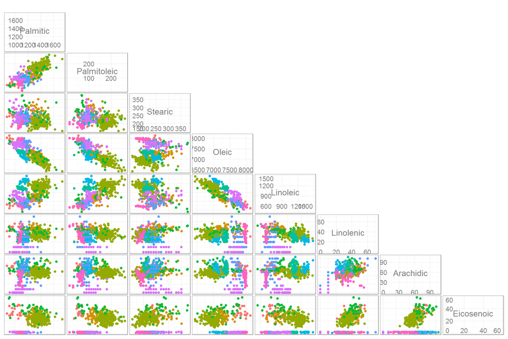

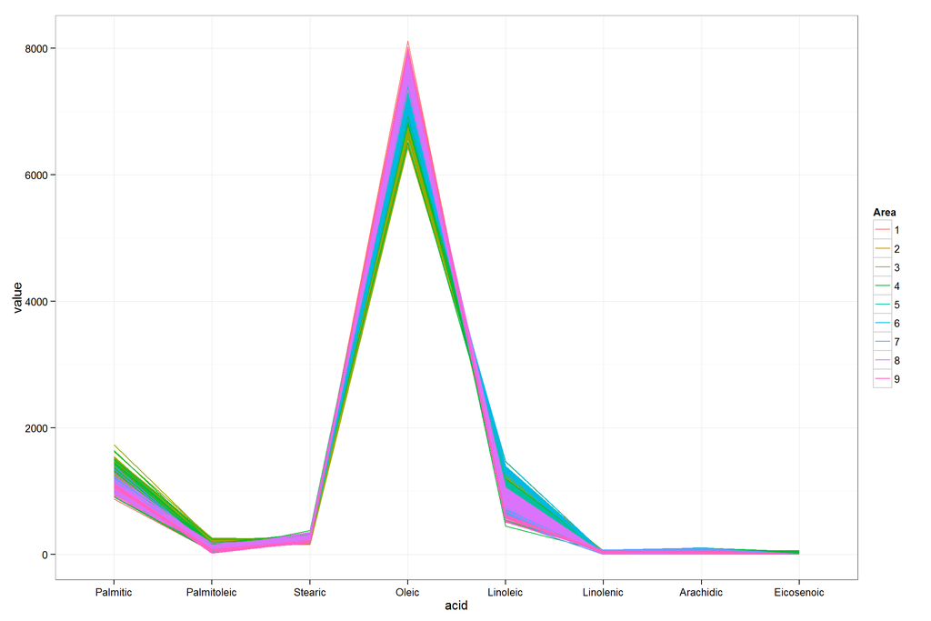

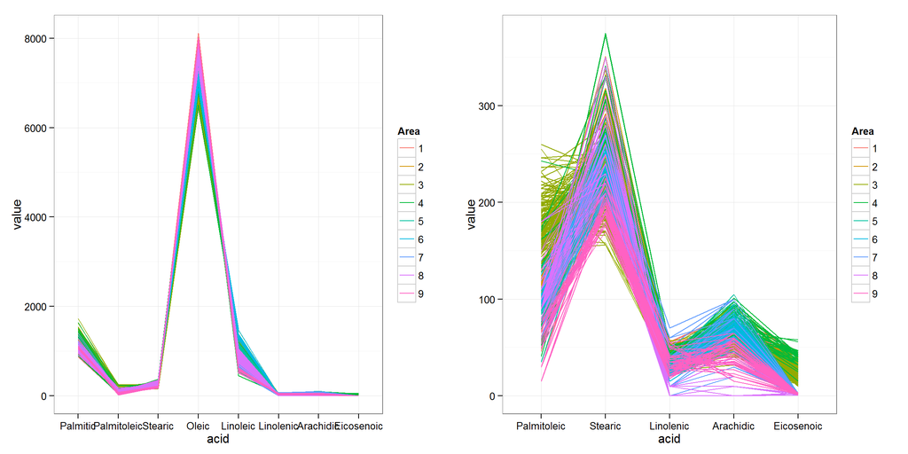

*LDA Training Classification Table:*

|  | Area 1 | Area 2 | Area 3 | Area 4 | Area 5 | Area 6 | Area 7 | Area 8 | Area 9 |
| --- | --- | --- | --- | --- | --- | --- | --- | --- | --- |
| Area 1 | 21 | 0 | 0 | 6 | 0 | 0 | 0 | 0 | 0 |
| Area 2 | 1 | 44 | 1 | 3 | 0 | 0 | 0 | 0 | 0 |
| Area 3 | 0 | 1 | 181 | 2 | 0 | 0 | 0 | 0 | 0 |
| Area 4 | 0 | 5 | 3 | 21 | 0 | 0 | 0 | 0 | 0 |
| Area 5 | 0 | 0 | 0 | 0 | 58 | 3 | 0 | 0 | 0 |
| Area 6 | 0 | 0 | 0 | 0 | 0 | 26 | 0 | 0 | 0 |
| Area 7 | 0 | 0 | 0 | 0 | 0 | 0 | 42 | 0 | 1 |
| Area 8 | 0 | 0 | 0 | 0 | 0 | 0 | 2 | 47 | 0 |
| Area 9 | 0 | 0 | 0 | 0 | 0 | 0 | 1 | 0 | 44 |

*LDA Test Classification Table:*

|  | Area 1 | Area 2 | Area 3 | Area 4 | Area 5 | Area 6 | Area 7 | Area 8 | Area 9 |
| --- | --- | --- | --- | --- | --- | --- | --- | --- | --- |
| Area 1 | 2 | 0 | 0 | 0 | 0 | 0 | 0 | 0 | 0 |
| Area 2 | 0 | 6 | 0 | 1 | 0 | 0 | 0 | 0 | 0 |
| Area 3 | 0 | 0 | 21 | 0 | 0 | 0 | 0 | 0 | 0 |
| Area 4 | 1 | 0 | 0 | 3 | 0 | 0 | 0 | 0 | 0 |
| Area 5 | 0 | 0 | 0 | 0 | 6 | 0 | 0 | 0 | 0 |
| Area 6 | 0 | 0 | 0 | 0 | 1 | 4 | 0 | 0 | 0 |
| Area 7 | 0 | 0 | 0 | 0 | 0 | 0 | 2 | 0 | 0 |
| Area 8 | 0 | 0 | 0 | 0 | 0 | 0 | 2 | 5 | 0 |
| Area 9 | 0 | 0 | 0 | 0 | 0 | 0 | 1 | 1 | 6 |

In the plot below, we can see the data projected onto the first two linear discriminants:

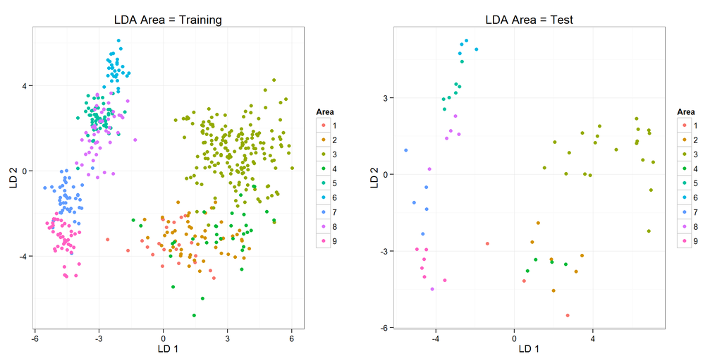

Fitting a QDA model using the training dataset and all eight acids to predict the area of origin for each olive oil, we get the following classification tables:

*QDA Training Classification Table:*

|  | Area 1 | Area 2 | Area 3 | Area 4 | Area 5 | Area 6 | Area 7 | Area 8 | Area 9 |
| --- | --- | --- | --- | --- | --- | --- | --- | --- | --- |
| Area 1 | 22 | 0 | 0 | 0 | 0 | 0 | 0 | 0 | 0 |
| Area 2 | 0 | 49 | 1 | 0 | 0 | 0 | 0 | 0 | 0 |
| Area 3 | 0 | 1 | 182 | 1 | 0 | 0 | 0 | 0 | 0 |
| Area 4 | 0 | 0 | 2 | 31 | 0 | 0 | 0 | 0 | 0 |
| Area 5 | 0 | 0 | 0 | 0 | 58 | 0 | 0 | 0 | 0 |
| Area 6 | 0 | 0 | 0 | 0 | 0 | 29 | 0 | 0 | 0 |
| Area 7 | 0 | 0 | 0 | 0 | 0 | 0 | 45 | 0 | 0 |
| Area 8 | 0 | 0 | 0 | 0 | 0 | 0 | 0 | 47 | 0 |
| Area 9 | 0 | 0 | 0 | 0 | 0 | 0 | 0 | 0 | 45 |

*QDA Test Classification Table:*

|  | Area 1 | Area 2 | Area 3 | Area 4 | Area 5 | Area 6 | Area 7 | Area 8 | Area 9 |
| --- | --- | --- | --- | --- | --- | --- | --- | --- | --- |
| Area 1 | 3 | 0 | 0 | 0 | 0 | 0 | 0 | 0 | 0 |
| Area 2 | 0 | 6 | 0 | 1 | 0 | 0 | 0 | 0 | 0 |
| Area 3 | 0 | 0 | 21 | 0 | 0 | 0 | 0 | 0 | 0 |
| Area 4 | 0 | 0 | 0 | 3 | 0 | 0 | 0 | 0 | 0 |
| Area 5 | 0 | 0 | 0 | 0 | 7 | 0 | 0 | 1 | 0 |
| Area 6 | 0 | 0 | 0 | 0 | 0 | 4 | 0 | 0 | 0 |
| Area 7 | 0 | 0 | 0 | 0 | 0 | 0 | 4 | 0 | 0 |
| Area 8 | 0 | 0 | 0 | 0 | 0 | 0 | 1 | 5 | 0 |
| Area 9 | 0 | 0 | 0 | 0 | 0 | 0 | 0 | 0 | 6 |

Fitting a multivariate logistic regression model to classify area of origin, again using the training dataset and all eight acids to predict the area of origin for each olive oil, we get the following classification tables:

*Logistic Regression Training Classification Table:*

|  | Area 1 | Area 2 | Area 3 | Area 4 | Area 5 | Area 6 | Area 7 | Area 8 | Area 9 |
| --- | --- | --- | --- | --- | --- | --- | --- | --- | --- |
| Area 1 | 22 | 0 | 0 | 1 | 0 | 0 | 0 | 0 | 0 |
| Area 2 | 0 | 46 | 0 | 2 | 0 | 0 | 0 | 0 | 0 |
| Area 3 | 0 | 2 | 182 | 4 | 0 | 0 | 0 | 0 | 0 |
| Area 4 | 0 | 2 | 3 | 25 | 0 | 0 | 0 | 0 | 0 |
| Area 5 | 0 | 0 | 0 | 0 | 58 | 0 | 0 | 0 | 0 |
| Area 6 | 0 | 0 | 0 | 0 | 0 | 29 | 0 | 0 | 0 |
| Area 7 | 0 | 0 | 0 | 0 | 0 | 0 | 45 | 0 | 0 |
| Area 8 | 0 | 0 | 0 | 0 | 0 | 0 | 0 | 47 | 0 |
| Area 9 | 0 | 0 | 0 | 0 | 0 | 0 | 0 | 0 | 45 |

*Logistic Regression Test Classification Table:*

|  | Area 1 | Area 2 | Area 3 | Area 4 | Area 5 | Area 6 | Area 7 | Area 8 | Area 9 |
| --- | --- | --- | --- | --- | --- | --- | --- | --- | --- |
| Area 1 | 3 | 0 | 0 | 0 | 0 | 0 | 0 | 0 | 0 |
| Area 2 | 0 | 6 | 1 | 1 | 0 | 0 | 0 | 0 | 0 |
| Area 3 | 0 | 0 | 20 | 0 | 0 | 0 | 0 | 0 | 0 |
| Area 4 | 0 | 0 | 0 | 3 | 0 | 0 | 0 | 0 | 0 |
| Area 5 | 0 | 0 | 0 | 0 | 7 | 0 | 0 | 0 | 0 |
| Area 6 | 0 | 0 | 0 | 0 | 0 | 4 | 0 | 0 | 0 |
| Area 7 | 0 | 0 | 0 | 0 | 0 | 0 | 4 | 1 | 1 |
| Area 8 | 0 | 0 | 0 | 0 | 0 | 0 | 1 | 5 | 0 |
| Area 9 | 0 | 0 | 0 | 0 | 0 | 0 | 0 | 0 | 5 |